# HousePriceDataAnalysis

### Overfitting

```r
split_data_mlr_clean <- createDataPartition(y =dataset.selection.clean$price,p=0.7,list=FALSE)

train_data_mlr_clean <- dataset.selection.clean[split_data_mlr_clean,]
test_data_mlr_clean <- dataset.selection.clean[-split_data_mlr_clean,]

lmfit1_mlr_clean <- train( price ~ bedrooms+sqft_living+yr_built+grade+view+sqft_lot+sqft_living15, data = train_data_mlr_clean,method="lm")
summary(lmfit1_mlr_clean)
```

```
Call:
lm(formula = .outcome ~ ., data = dat)

Residuals:
    Min      1Q  Median      3Q     Max
-398866  -79583   -6199   74400  512795

Coefficients:
                Estimate Std. Error t value Pr(>|t|)
(Intercept)    4.283e+06  8.512e+04  50.314  < 2e-16 ***
bedrooms      -1.208e+04  1.974e+03  -6.116 9.94e-10 ***
sqft_living    9.204e+01  3.692e+00  24.929  < 2e-16 ***
yr_built      -2.347e+03  4.558e+01 -51.502  < 2e-16 ***
grade          8.762e+04  2.044e+03  42.872  < 2e-16 ***
view           2.187e+04  2.445e+03   8.945  < 2e-16 ***
sqft_lot      -1.458e+01  4.668e-01 -31.228  < 2e-16 ***
sqft_living15  5.434e+01  3.922e+00  13.856  < 2e-16 ***
---
Signif. codes:  0 ‘***’ 0.001 ‘**’ 0.01 ‘*’ 0.05 ‘.’ 0.1 ‘ ’ 1

Residual standard error: 115000 on 9700 degrees of freedom
Multiple R-squared:  0.4788,    Adjusted R-squared:  0.4784
F-statistic:  1273 on 7 and 9700 DF,  p-value: < 2.2e-16
```

#### RMSE

```r
predicted_test_mlr_clean <- predict(lmfit1_mlr_clean,test_data_mlr_clean)
model_test_1_mlr_clean <- data.frame(obs = test_data_mlr_clean$price,pred=predicted_test_mlr_clean)
defaultSummary(model_test_1_mlr_clean)
```

```
        RMSE     Rsquared          MAE
1.167813e+05 4.731244e-01 9.300586e+04
```

#### Ploteo

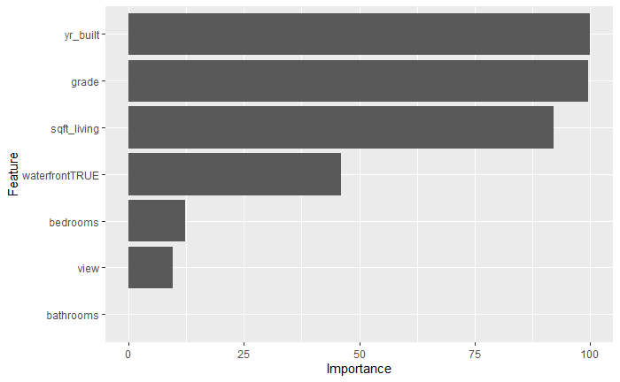

```r
ggplot(varImp(lmfit1_mlr))
```

### Cross Validation

```r
control1_mlr_clean <- trainControl(method="cv",number=10)
lmfit2_mlr_clean <- train(price ~. ,data = dataset.selection.clean,method="lm",trControl=control1_mlr_clean,metric="Rsquared")
summary(lmfit2_mlr_clean)
```

```
Call:
lm(formula = .outcome ~ ., data = dat)

Residuals:
    Min      1Q  Median      3Q     Max
-404694  -80911   -6289   74600  511166

Coefficients:
                Estimate Std. Error t value Pr(>|t|)
(Intercept)    4.337e+06  7.120e+04  60.906  < 2e-16 ***
bedrooms      -1.151e+04  1.654e+03  -6.959 3.59e-12 ***
sqft_living    9.094e+01  3.096e+00  29.371  < 2e-16 ***
yr_built      -2.377e+03  3.814e+01 -62.314  < 2e-16 ***
grade          8.828e+04  1.716e+03  51.436  < 2e-16 ***
view           2.159e+04  2.083e+03  10.363  < 2e-16 ***
sqft_lot      -1.424e+01  3.905e-01 -36.463  < 2e-16 ***
sqft_living15  5.305e+01  3.283e+00  16.158  < 2e-16 ***
---
Signif. codes:  0 ‘***’ 0.001 ‘**’ 0.01 ‘*’ 0.05 ‘.’ 0.1 ‘ ’ 1

Residual standard error: 115600 on 13857 degrees of freedom
Multiple R-squared:  0.4771,    Adjusted R-squared:  0.4768
F-statistic:  1806 on 7 and 13857 DF,  p-value: < 2.2e-16
```

#### RMSE

```r
predicted_test_2_mlr_clean <- predict(lmfit2_mlr_clean,dataset.selection.clean)
model_test_2_mlr_clean <- data.frame(obs = dataset.selection.clean$price,pred=predicted_test_2_mlr_clean)
defaultSummary(model_test_2_mlr_clean)
```

```
        RMSE     Rsquared          MAE
1.155187e+05 4.771075e-01 9.210670e+04
```

#### Ploteo

```r
ggplot(varImp(lmfit2_mlr_clean))
```

[output not shown]

### Boostrap

```r
control3_mlr_clean <- trainControl(method="boot",number=100)
lmfit3_mlr_clean <- train(price ~. ,data = dataset.selection.clean,method="lm",trControl=control1_mlr_clean)
summary(lmfit3_mlr_clean)
```

```
Call:
lm(formula = .outcome ~ ., data = dat)

Residuals:
    Min      1Q  Median      3Q     Max
-404694  -80911   -6289   74600  511166

Coefficients:
                Estimate Std. Error t value Pr(>|t|)
(Intercept)    4.337e+06  7.120e+04  60.906  < 2e-16 ***
bedrooms      -1.151e+04  1.654e+03  -6.959 3.59e-12 ***
sqft_living    9.094e+01  3.096e+00  29.371  < 2e-16 ***
yr_built      -2.377e+03  3.814e+01 -62.314  < 2e-16 ***
grade          8.828e+04  1.716e+03  51.436  < 2e-16 ***
view           2.159e+04  2.083e+03  10.363  < 2e-16 ***
sqft_lot      -1.424e+01  3.905e-01 -36.463  < 2e-16 ***
sqft_living15  5.305e+01  3.283e+00  16.158  < 2e-16 ***
---
Signif. codes:  0 ‘***’ 0.001 ‘**’ 0.01 ‘*’ 0.05 ‘.’ 0.1 ‘ ’ 1

Residual standard error: 115600 on 13857 degrees of freedom
Multiple R-squared:  0.4771,    Adjusted R-squared:  0.4768
F-statistic:  1806 on 7 and 13857 DF,  p-value: < 2.2e-16
```

#### RMSE

```r
predicted_test_3_mlr_clean <- predict(lmfit3_mlr_clean,dataset.selection.clean)
model_test_3_mlr_clean <- data.frame(obs = dataset.selection.clean$price,pred=predicted_test_3_mlr_clean)
defaultSummary(model_test_3_mlr_clean)
```

```
        RMSE     Rsquared          MAE
1.155187e+05 4.771075e-01 9.210670e+04
```

#### Ploteo

```r
ggplot(varImp(lmfit3_mlr_clean))
```

[output not shown]

Podemos decir que no hay variaciones significativas. El coeficiente de determinación R-Squared es bueno al igual que Adjusted R-Squared ya que tienen valores altos pero en este caso es menor en un 20% (47.53%) al que se obtuvo con el dataset anterior(64.98%). Podemos decir que las gráficas mejoraron respecto las anteriores. De todas maneras, se siguen observando valores alejados, dispersos e influyentes. Analizando lo obtenido, vemos que siguen apareciendo las mismas caracteristicas como las mas importantes. En cuanto a los RMSE, Boostrap y Cross Validation poseen el mismo valor(1.155187e+05) y el mayor que es 1.167813e+05 se obtiene evaluando el overfitting.

# **Regresión Polinomial**

La Regresión Polinomial es un caso especial de la Regresión Lineal, extiende el modelo lineal al agregar predictores adicionales, obtenidos al elevar cada uno de los predictores originales a una potencia.

## **Dataset Crudo**

```r
mlr_poly_raw <- lm(formula = price ~ poly(sqft_living,2)+bathrooms+yr_built+
                   grade+waterfront+view+bedrooms,data=dataset.selection.raw)
summary(mlr_poly_raw)
```

```
Call:
lm(formula = price ~ poly(sqft_living, 2) + bathrooms + yr_built +
    grade + waterfront + view + bedrooms, data = dataset.selection.raw)

Residuals:
     Min       1Q   Median       3Q      Max
-4822295  -106287   -10750    84863  2446717

Coefficients:
                        Estimate Std. Error t value Pr(>|t|)
(Intercept)            6.245e+06  1.132e+05  55.167   <2e-16 ***
poly(sqft_living, 2)1  1.873e+07  4.250e+05  44.076   <2e-16 ***
poly(sqft_living, 2)2  9.774e+06  2.177e+05  44.899   <2e-16 ***
bathrooms              6.146e+04  3.175e+03  19.359   <2e-16 ***
yr_built              -3.466e+03  5.977e+01 -57.991   <2e-16 ***
grade                  1.358e+05  2.027e+03  66.972   <2e-16 ***
waterfrontTRUE         5.558e+05  1.788e+04  31.092   <2e-16 ***
view                   4.254e+04  2.134e+03  19.934   <2e-16 ***
bedrooms              -1.680e+04  1.990e+03  -8.441   <2e-16 ***
---
Signif. codes:  0 ‘***’ 0.001 ‘**’ 0.01 ‘*’ 0.05 ‘.’ 0.1 ‘ ’ 1

Residual standard error: 207800 on 21604 degrees of freedom
Multiple R-squared:  0.6797,    Adjusted R-squared:  0.6796
F-statistic:  5731 on 8 and 21604 DF,  p-value: < 2.2e-16
```

Podemos observar que se agregó el predictor sqft_living. Los resultados son buenos y se logra casi un 68% en Adjusted R-squared. Por lo tanto al aplicar una regresión polinomial con el dataset crudo es más optimo para la predicción de los precios de las casas.

### Índice de Confianza

```r
confint(mlr_poly_raw)
```

```
                             2.5 %       97.5 %
(Intercept)            6022843.028  6466586.937
poly(sqft_living, 2)1 17899267.885 19565319.129
poly(sqft_living, 2)2  9346886.998 10200221.882
bathrooms                55234.537    67679.114
yr_built                 -3583.224    -3348.919
grade                   131790.108   139736.914
waterfrontTRUE          520728.442   590801.290
view                     38358.826    46725.108
bedrooms                -20701.787   -12898.988
```

### Validación del modelo

Podemos observar que el modelo no es simétrico y tiene una tendencia hacia la derecha.

```r
stem(mlr_poly_raw$residuals)
```

```
  The decimal point is 6 digit(s) to the right of the |

  -4 | 8
  -4 |
  -3 |
  -3 |
  -2 |
  -2 | 0
  -1 | 8
  -1 | 433211100
  -0 | 99999999999998888888888887777777777777777777777777777777777777776666+123
  -0 | 44444444444444444444444444444444444444444444444444444444444444444444+11170
   0 | 00000000000000000000000000000000000000000000000000000000000000000000+9537
   0 | 55555555555555555555555555555555555555555555555555555555555555555555+342
   1 | 00000000000000000000000000000001111111122222222222222233333333333333+2
   1 | 5555555556666667788899
   2 | 03344
```

### Predecidos vs Actuales

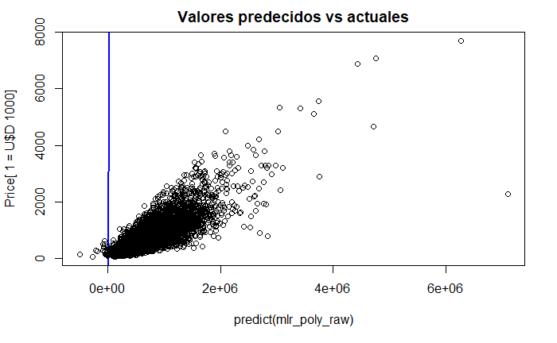

```r
plot(predict(mlr_poly_raw),dataset.selection.raw$price/1000, ylab="Price[ 1 = U$D 1000]",
     main="Valores predecidos vs actuales",
abline(a=0,b=1,col="blue",lwd=2))
```

### Residuales

Podemos ver que los residuales tienen una aglomeración y cercana al valor 0.

```r
plot(residuals(mlr_poly_raw))
abline(a=0,b=0,col="blue",lwd=2)
```

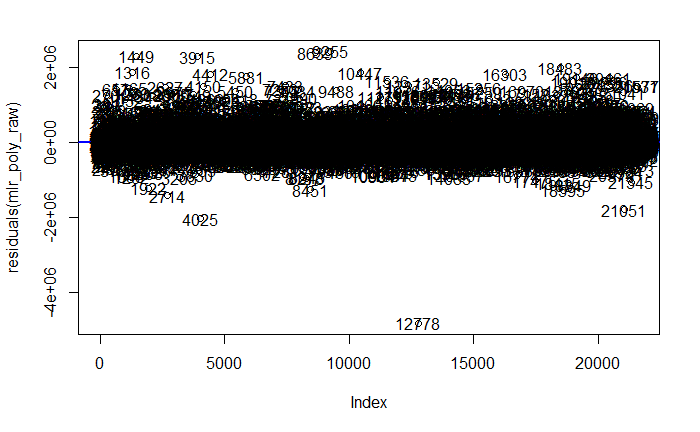

```r
text(residuals(mlr_poly_raw))
```